# Acute Myocardial Infarction - 30-day mortality

Data analysis and prognostic model building.

Arhin Claribel Ajua Tawiah, Bragagnolo Sofia, Guccione Anna, Maia Tavora Leticia

**Acute Myocardial Infarction (MI)** (“heart attack”) is caused by the formation of a clot in one of the coronary arteries that supply blood to the heart muscle. Mortality is substantial in the period immediately after the event (and during the years after surviving the initial infarction). The risk of **30-day mortality** strongly depends on various prognostic factors.

The data we use here are a sub-sample coming from a trial, a four-arm randomized study that compared the efficacy of different intravenous thrombolytic regimens for acute myocardial infarction.

Aim of this project is to predict the probability of 30-days mortality.

# 1 Question 1: Initial Data Analysis

> Start with an initial data analysis, comparing patients dead versus patients alive at 30 days. Insert also a column with the total population descriptive statistics. Include also a new variable, the Body Mass Index.

## 1.1 Data loading

```r
ami_data <- read_excel('./AMI_data.xlsx')
```

### 1.1.1 Dimensions

```r
data.frame(
  'patients'  = nrow(ami_data),
  'factors'   = ncol(ami_data)) %>% kable(col.names = c("Num of patients", "Num of prognostic factors"), caption = "Dataset dimensions") %>%
  kable_styling(full_width = FALSE, bootstrap_options = c("bordered"))
```

Dataset dimensions

| Num of patients | Num of prognostic factors |
| --- | --- |
| 3661 | 21 |

All variables are numerical

```r
head(ami_data)
```

```
## # A tibble: 6 × 21
##   day30   sex   age   a65 killip   sho   dia   hyp   hrt   ant   pmi   hei   wei
##   <dbl> <dbl> <dbl> <dbl>  <dbl> <dbl> <dbl> <dbl> <dbl> <dbl> <dbl> <dbl> <dbl>
## 1     0     0  70.3     1      1     0     0     0     0     1     0  177.  84
## 2     0     0  59.8     0      1     0     1     0     0     1     0  172  115
## 3     0     0  59.0     0      1     0     0     0     1     0     0  170   76
## 4     1     1  80.4     1      1     0     0     0     1     0     0  155.  50
## 5     0     0  64.8     0      1     0     0     1     0     0     0  167   97.4
## 6     0     0  53.9     0      1     0     0     0     0     1     0  171  100
## # ℹ 8 more variables: htn <dbl>, smk <dbl>, lip <dbl>, pan <dbl>, fam <dbl>,
## #   ste <dbl>, st4 <dbl>, ttr <dbl>
```

### 1.1.2 Factors labels

The factors in the observation include:

- personal factors such as age, gender, height and weight
- conditions like hypertension, diabetes, smoking
- family history and the history of previous cardiovascular events (previous MI, angina, stroke, bypass surgery)
- relevant characteristics such as the location of the infarction and the extent of ECG abnormalities
- the acute state of the patient as reflected by the Killip score

```r
pretty_labels <- list(
    sex    ~ "Sex",
    age    ~ "Age (years)",
    bmi    ~ "Body Mass Index (kg/m²)",
    killip ~ "Killip class",
    sho    ~ "Shock (Killip 3/4)",
    dia    ~ "Diabetes",
    hyp    ~ "Hypotension (SBP < 100)",
    hrt    ~ "Tachycardia (pulse > 80)",
    ant    ~ "Anterior infarct location",
    pmi    ~ "Previous MI",
    htn    ~ "Hypertension history",
    smk    ~ "Smoking status",
    lip    ~ "Hypercholesterolaemia",
    pan    ~ "Previous angina",
    fam    ~ "Family history of MI",
    ste    ~ "ST elevation (n leads)",
    st4    ~ "ST elevation > 4 leads",
    ttr    ~ "Time to pain relief > 1h"
  )
status_colors <- c("Alive" = "#519e8a", "Dead" = "#E5625E")
```

### 1.1.3 Missing values

Checking for missing values:

```r
colSums(is.na(ami_data))
```

```
##  day30    sex    age    a65 killip    sho    dia    hyp    hrt    ant    pmi
##      0      0      0      0      0      0      0      0      0      0      0
##    hei    wei    htn    smk    lip    pan    fam    ste    st4    ttr
##      0      0      0      0      0      0      0      0      0      0
```

There is no missing values in the data.

## 1.2 Data preparation

### 1.2.1 BMI factor

We create the BMI column following the formula.

```r
ami_data$bmi <- ami_data$wei/(ami_data$hei/100)^2
```

### 1.2.2 Converting to factors

We convert the `day30` column into a factor for easier interpretation. We do the same with all the other binary variables. And for ordinal variables too.

```r
ami_data <- ami_data %>%
  mutate(
    day30 = factor(day30, levels=c(0,1), labels=c("Alive","Dead")),
    sex = factor(sex, levels=c(0, 1), labels=c("Male", "Female")),
    a65 = factor(a65, levels=c(0, 1), labels=c("No", "Yes")),
    sho = factor(sho, levels=c(0, 1), labels=c("No","Yes")),
    dia = factor(dia,   levels=c(0,1), labels=c("No","Yes")),
    hyp = factor(hyp,   levels=c(0,1), labels=c("No","Yes")),
    hrt = factor(hrt,   levels=c(0,1), labels=c("No","Yes")),
    ant = factor(ant,   levels=c(0,1), labels=c("No","Yes")),
    pmi = factor(pmi,   levels=c(0,1), labels=c("No","Yes")),
    htn = factor(htn,   levels=c(0,1), labels=c("No","Yes")),
    lip = factor(lip,   levels=c(0,1), labels=c("No","Yes")),
    pan = factor(pan,   levels=c(0,1), labels=c("No","Yes")),
    fam = factor(fam,   levels=c(0,1), labels=c("No","Yes")),
    st4 = factor(st4,   levels=c(0,1), labels=c("No","Yes")),
    ttr = factor(ttr,   levels=c(0,1), labels=c("No","Yes")),
    killip = factor(killip, levels=c(1,2,3,4)),
    smk = factor(ami_data$smk, levels=c(1,2,3), labels=c("Never","Ex","Current"), ordered=TRUE))

head(ami_data)
```

```
## # A tibble: 6 × 22
##   day30 sex     age a65   killip sho   dia   hyp   hrt   ant   pmi     hei   wei
##   <fct> <fct> <dbl> <fct> <fct>  <fct> <fct> <fct> <fct> <fct> <fct> <dbl> <dbl>
## 1 Alive Male   70.3 Yes   1      No    No    No    No    Yes   No     177.  84
## 2 Alive Male   59.8 No    1      No    Yes   No    No    Yes   No     172  115
## 3 Alive Male   59.0 No    1      No    No    No    Yes   No    No     170   76
## 4 Dead  Fema…  80.4 Yes   1      No    No    No    Yes   No    No     155.  50
## 5 Alive Male   64.8 No    1      No    No    Yes   No    No    No     167   97.4
## 6 Alive Male   53.9 No    1      No    No    No    No    Yes   No     171  100
## # ℹ 9 more variables: htn <fct>, smk <ord>, lip <fct>, pan <fct>, fam <fct>,
## #   ste <dbl>, st4 <fct>, ttr <fct>, bmi <dbl>
```

## 1.3 Exploring the data

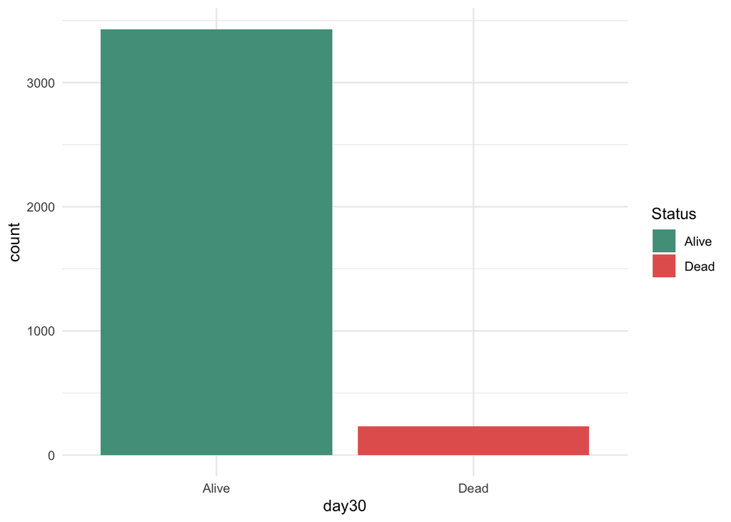

```r
ggplot(ami_data) +
  geom_bar(aes(x = day30, fill = day30), stat = "count") +
  scale_fill_manual(name = "Status", values = status_colors) +
  theme_minimal()
```

### 1.3.1 Cumulative incidence

```r
n_dead  <- sum(ami_data$day30 == "Dead")
n_total <- nrow(ami_data)
inc <- binom.exact(n_dead, n_total)
data.frame(
  'Deaths'  = n_dead,
  'Total'   = n_total,
  'Perc' = round(inc$proportion * 100, 2),
  'CI lower' = round(inc$lower * 100, 2),
  'CI upper' = round(inc$upper * 100, 2)
) %>% kable(col.names = c("30-day status", "N", "%", "95% CI lower", "95% CI upper"), caption = "Cumulative incidence at 30 days") %>%
  kable_styling(full_width = FALSE, bootstrap_options = c("bordered"))
```

Cumulative incidence at 30 days

| 30-day status | N | % | 95% CI lower | 95% CI upper |
| --- | --- | --- | --- | --- |
| 231 | 3661 | 6.31 | 5.54 | 7.15 |

### 1.3.2 Descriptive statistics

Here we present the table with the characteristics ordered by the absolute value of the SMD.

```r
tbl_summary(ami_data, by=day30,
            include = c(age, killip, sho, ant, hrt, ste, st4, smk, hyp, pmi, sex, bmi, pan, ttr, dia, fam, htn, lip),
            label = pretty_labels) %>% add_overall() %>% add_stat_label() %>% bold_labels() %>% add_difference(everything() ~ "smd") %>% modify_spanning_header(all_stat_cols() ~ "**After 30 days**") %>% modify_caption(
    "**Table 1. Baseline characteristics by 30-day vital status**"
  )
```

**Table 1. Baseline characteristics by 30-day vital status**

| **Characteristic** | **After 30 days** **Overall** N = 3,661 | **After 30 days** **Alive** N = 3,430 | **After 30 days** **Dead** N = 231 | **Difference**<sup>1</sup> | **95% CI**<sup>1</sup> |  |  |
| --- | --- | --- | --- | --- | --- | --- | --- |
| Age (years), Median (Q1, Q3) | 61 (52, 70) | 60 (51, 69) | 73 (65, 79) |  |  | -0.98 | -1.1, -0.85 |
| Killip class, n (%) |  |  |  | 0.67 | 0.54, 0.80 |  |  |
| 1 | 3,166 (86%) | 3,022 (88%) | 144 (62%) |  |  |  |  |
| 2 | 433 (12%) | 376 (11%) | 57 (25%) |  |  |  |  |
| 3 | 43 (1.2%) | 24 (0.7%) | 19 (8.2%) |  |  |  |  |
| 4 | 19 (0.5%) | 8 (0.2%) | 11 (4.8%) |  |  |  |  |
| Shock (Killip 3/4), n (%) | 62 (1.7%) | 32 (0.9%) | 30 (13%) | 0.49 | 0.35, 0.62 |  |  |
| Anterior infarct location, n (%) | 1,347 (37%) | 1,215 (35%) | 132 (57%) | 0.45 | 0.31, 0.58 |  |  |
| Tachycardia (pulse > 80), n (%) | 1,161 (32%) | 1,043 (30%) | 118 (51%) | 0.43 | 0.30, 0.56 |  |  |
| ST elevation (n leads), Median (Q1, Q3) | 4.00 (3.00, 5.00) | 4.00 (3.00, 5.00) | 5.00 (3.00, 6.00) | -0.35 | -0.48, -0.22 |  |  |
| ST elevation > 4 leads, n (%) | 1,349 (37%) | 1,227 (36%) | 122 (53%) | 0.35 | 0.21, 0.48 |  |  |
| Smoking status, n (%) |  |  |  | 0.34 | 0.21, 0.48 |  |  |
| Never | 1,451 (40%) | 1,393 (41%) | 58 (25%) |  |  |  |  |
| Ex | 1,185 (32%) | 1,099 (32%) | 86 (37%) |  |  |  |  |
| Current | 1,025 (28%) | 938 (27%) | 87 (38%) |  |  |  |  |
| Hypotension (SBP < 100), n (%) | 319 (8.7%) | 274 (8.0%) | 45 (19%) | 0.34 | 0.21, 0.47 |  |  |
| Previous MI, n (%) | 617 (17%) | 548 (16%) | 69 (30%) | 0.34 | 0.20, 0.47 |  |  |
| Sex, n (%) |  |  |  | 0.32 | 0.18, 0.45 |  |  |
| Male | 2,721 (74%) | 2,581 (75%) | 140 (61%) |  |  |  |  |
| Female | 940 (26%) | 849 (25%) | 91 (39%) |  |  |  |  |
| Body Mass Index (kg/m²), Median (Q1, Q3) | 26.8 (24.2, 29.9) | 26.9 (24.3, 30.0) | 25.3 (22.7, 28.0) | 0.32 | 0.19, 0.46 |  |  |
| Previous angina, n (%) | 1,282 (35%) | 1,176 (34%) | 106 (46%) | 0.24 | 0.11, 0.37 |  |  |
| Time to pain relief > 1h, n (%) | 2,158 (59%) | 1,998 (58%) | 160 (69%) | 0.23 | 0.10, 0.36 |  |  |
| Diabetes, n (%) | 481 (13%) | 440 (13%) | 41 (18%) | 0.14 | 0.00, 0.27 |  |  |
| Family history of MI, n (%) | 1,672 (46%) | 1,580 (46%) | 92 (40%) | 0.13 | -0.01, 0.26 |  |  |
| Hypertension history, n (%) | 1,451 (40%) | 1,348 (39%) | 103 (45%) | 0.11 | -0.03, 0.24 |  |  |
| Hypercholesterolaemia, n (%) | 1,455 (40%) | 1,372 (40%) | 83 (36%) | 0.08 | -0.05, 0.22 |  |  |

<sup>1</sup> Standardized Mean Difference  
Abbreviation: CI = Confidence Interval

### 1.3.3 Correlation matrix

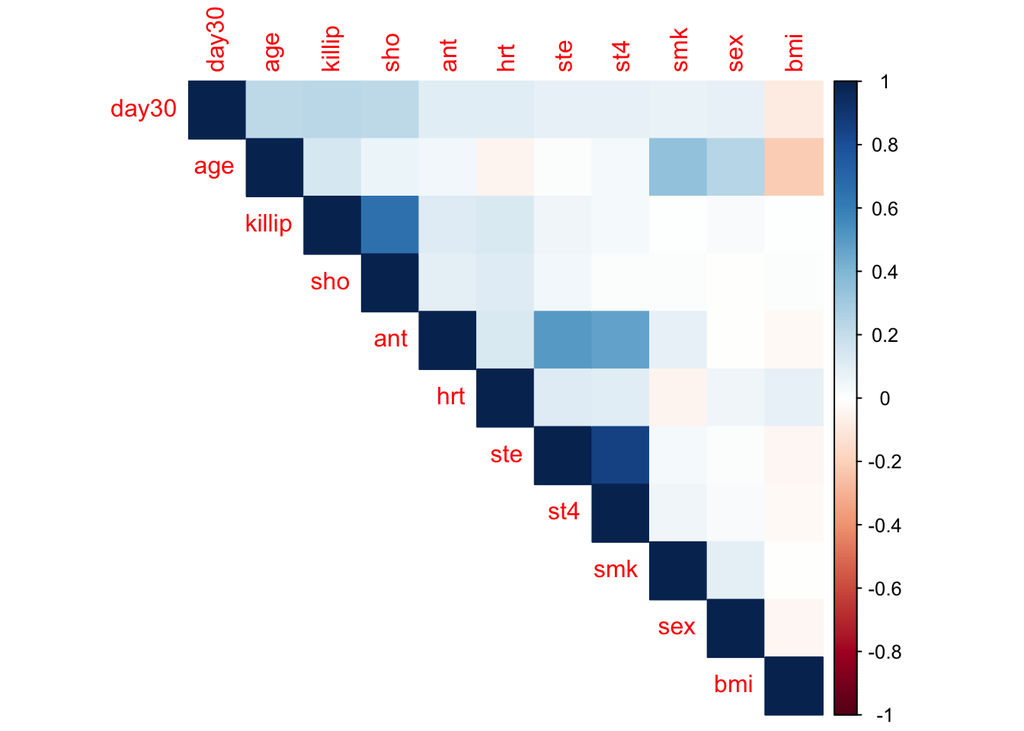

```r
small_ami_data <- ami_data %>%
  select(day30, age, killip, sho, ant, hrt, ste, st4, smk, sex, bmi) %>% mutate(across(everything(), ~ as.numeric(.x) - 1))
corr <- cor(small_ami_data, use = "complete.obs")
corrplot(corr, method = "color", type = "upper")
```

## Visual summary Now we present some visualization for key predictors.

### 1.3.4 Age

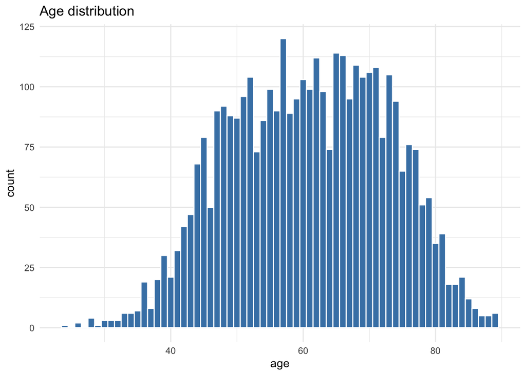

```r
# Histogram for age
ggplot(ami_data, aes(x = age)) +
  geom_histogram(binwidth = 1, fill = "steelblue", color = "white") +
  labs(title = "Age distribution") + theme_minimal()
```

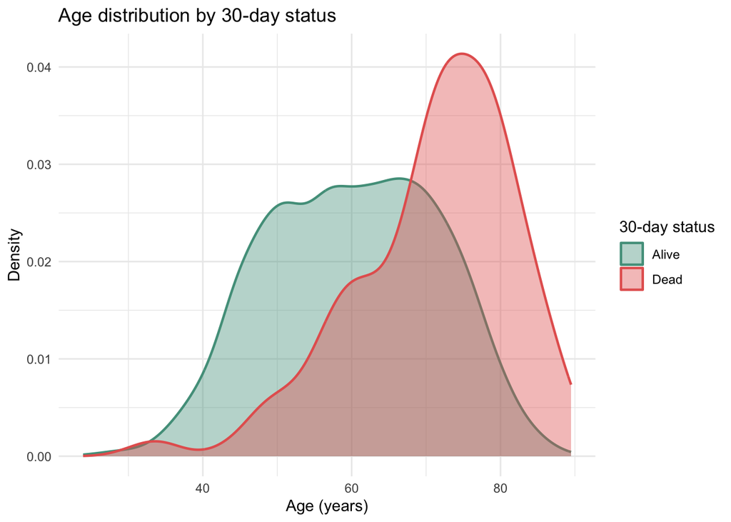

```r
ggplot(ami_data, aes(x = age, fill = day30, colour = day30)) +
  geom_density(alpha = 0.4, linewidth = 0.8) +
  scale_fill_manual(values  = status_colors) +
  scale_colour_manual(values = status_colors) +
  labs(title = "Age distribution by 30-day status", x = "Age (years)", y = "Density",
       fill = "30-day status", colour = "30-day status") +
  theme_bw(base_size = 12) +
  theme(legend.position = "bottom", plot.title = element_text(face = "bold")) + theme_minimal()
```

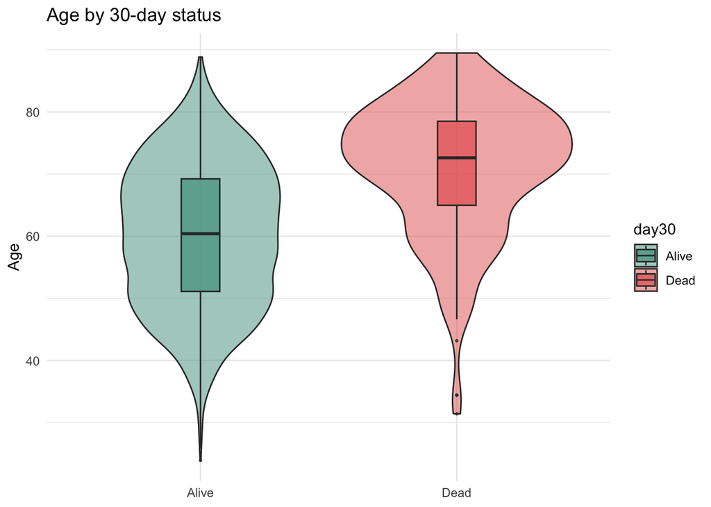

```r
ggplot(ami_data, aes(x = day30, y = age, fill = day30)) +
  geom_violin(alpha = 0.5, trim = TRUE) +
  geom_boxplot(width = 0.15, outlier.size = 0.5, alpha = 0.7) +
  scale_fill_manual(values = status_colors) +
  labs(title = "Age by 30-day status", x = NULL, y = "Age") +
  theme_bw(base_size = 11) +
  theme(legend.position = "none") + theme_minimal()
```

### 1.3.5 Killip

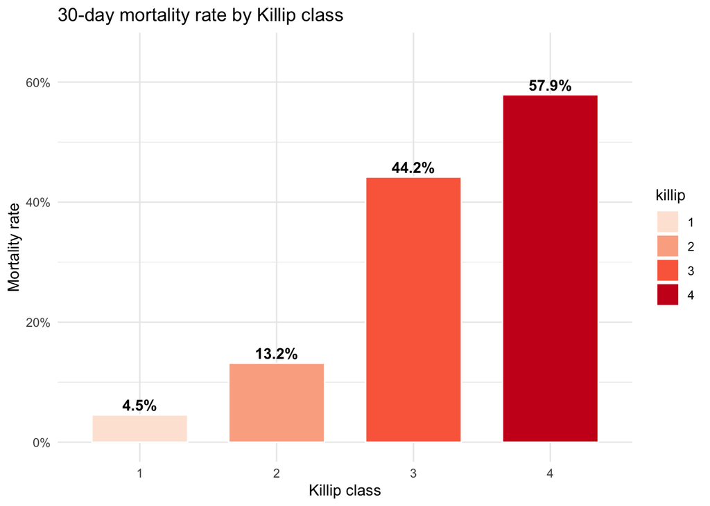

```r
ami_data %>%
  count(killip, day30) %>%
  group_by(killip) %>%
  mutate(pct = n / sum(n)) %>%
  filter(day30 == "Dead") %>%
  ggplot(aes(x = killip, y = pct, fill = killip)) +
  geom_col(colour = "white", width = 0.7) +
  geom_text(aes(label = scales::percent(pct, accuracy = 0.1)),
            vjust = -0.4, size = 3.8, fontface = "bold") +
  scale_y_continuous(labels = scales::percent, limits = c(0, 0.65)) +
  scale_fill_brewer(palette = "Reds") +
  labs(title = "30-day mortality rate by Killip class",
       x = "Killip class", y = "Mortality rate") +
  theme_bw(base_size = 12) +
  theme(legend.position = "none", plot.title = element_text(face = "bold")) + theme_minimal()
```

### 1.3.6 ST elevation

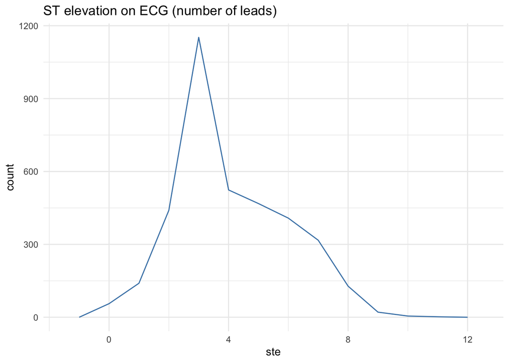

```r
ggplot(ami_data, aes(x = ste)) +
  geom_freqpoly(binwidth = 1, color = "steelblue") +
  labs(title = "ST elevation on ECG (number of leads)") + theme_minimal()
```

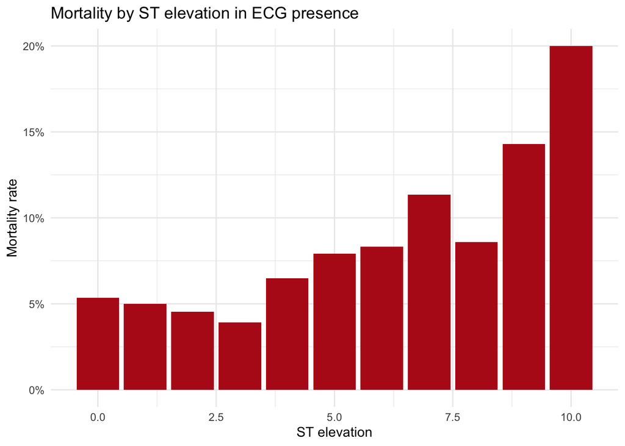

```r
ami_data %>%
  group_by(ste, day30) %>%
  summarise(n = n(), .groups = "drop") %>%
  group_by(ste) %>%
  mutate(pct = n / sum(n)) %>%
  filter(day30 == "Dead") %>%
  ggplot(aes(x = ste, y = pct)) +
  geom_col(fill = "#B71C1C") +
  scale_y_continuous(labels = scales::percent) +
  labs(title = "Mortality by ST elevation in ECG presence",
       x = "ST elevation", y = "Mortality rate") +
  theme_bw(base_size = 11) + theme_minimal()
```

### 1.3.7 Sex

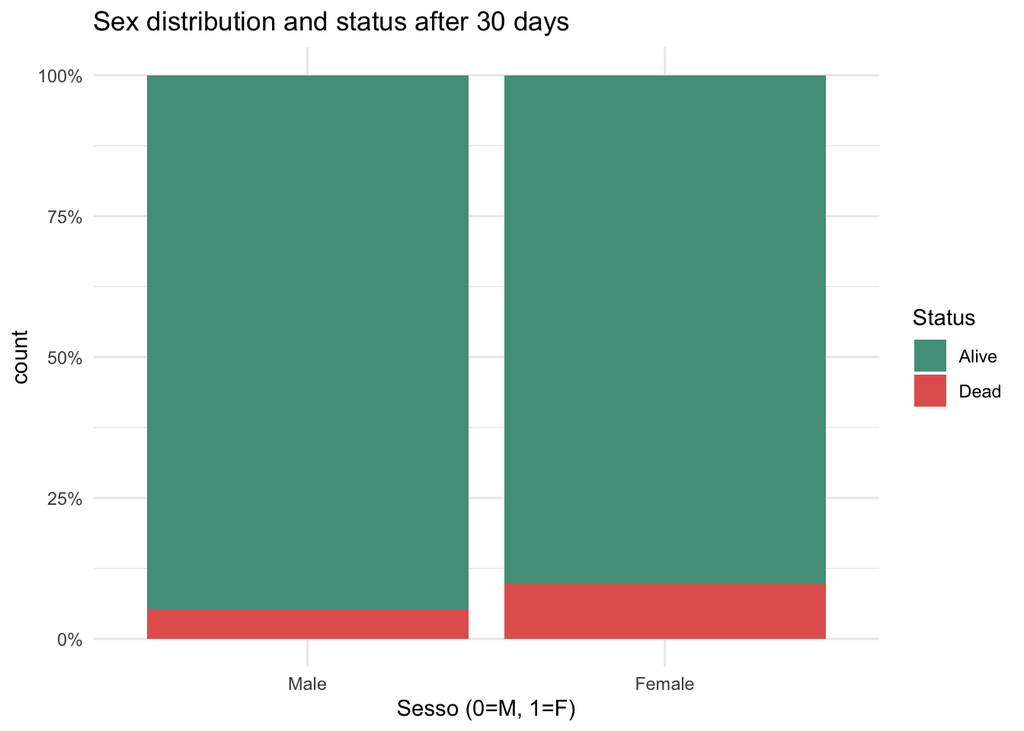

```r
# Bar chart: sex + outcome
ggplot(ami_data, aes(x = factor(sex), fill = day30)) +
  scale_fill_manual(name = "Status", values = status_colors) +
  geom_bar(position = "fill") +
  scale_y_continuous(labels = scales::percent) +
  labs(title = "Sex distribution and status after 30 days", x = "Sesso (0=M, 1=F)") + theme_minimal()
```

### 1.3.8 BMI

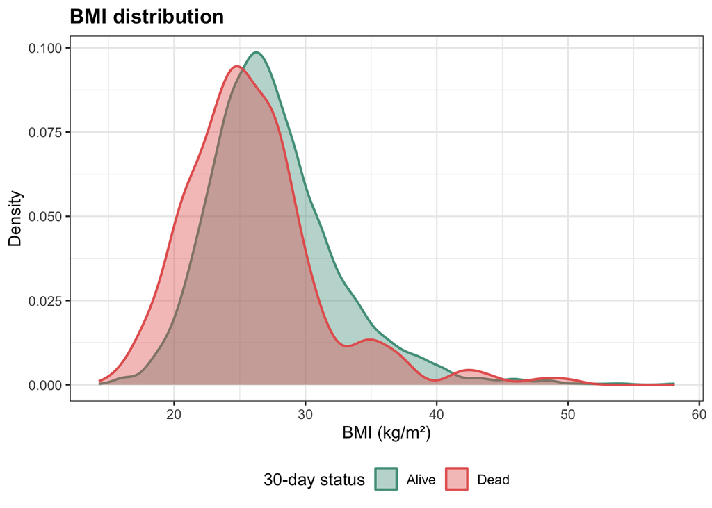

```r
ggplot(ami_data, aes(x = bmi, fill = day30, colour = day30)) +
  geom_density(alpha = 0.4, linewidth = 0.8) +
  scale_fill_manual(values  = status_colors) +
  scale_colour_manual(values = status_colors) +
  labs(title = "BMI distribution", x = "BMI (kg/m²)", y = "Density",
       fill = "30-day status", colour = "30-day status") +
  theme_bw(base_size = 12) +
  theme(legend.position = "bottom", plot.title = element_text(face = "bold"))
```

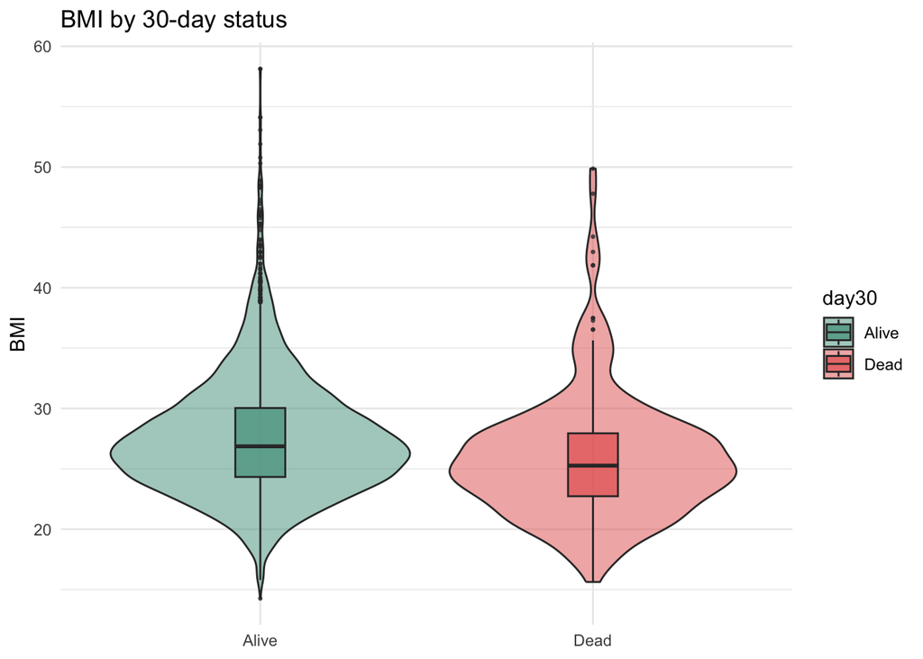

```r
# Violinplot: BMI + outcome
ggplot(ami_data, aes(x = day30, y = bmi, fill = day30)) +
  geom_violin(alpha = 0.5, trim = TRUE) +
  geom_boxplot(width = 0.15, outlier.size = 0.5, alpha = 0.7) +
  scale_fill_manual(values = status_colors) +
  labs(title = "BMI by 30-day status", x = NULL, y = "BMI") +
  theme_bw(base_size = 11) +
  theme(legend.position = "none") + theme_minimal()
```

# 2 Question 2

> Perform univariable regression analyses (crude association measures) of all candidate predictors for your prognostic model. For the continuous variables is the linear effect reasonable?

## 2.1 Crude odds

```r
tbl_uvregression(
  ami_data,
  label = pretty_labels,
  method   = glm,
  y        = day30,
  method.args = list(family = binomial),
  exponentiate = TRUE,
  include  = c(age, killip, sho, ant, hrt, ste, st4, smk, hyp, pmi, sex, bmi, pan, ttr, dia, fam, htn, lip)
) %>% bold_labels()
```

| **Characteristic** | **N** | **OR** | **95% CI** | **p-value** |
| --- | --- | --- | --- | --- |
| Age (years) | 3,661 | 1.10 | 1.08, 1.11 | <0.001 |
| Killip class | 3,661 |  |  |  |
| 1 |  | — | — |  |
| 2 |  | 3.18 | 2.28, 4.38 | <0.001 |
| 3 |  | 16.6 | 8.80, 31.0 | <0.001 |
| 4 |  | 28.9 | 11.5, 75.6 | <0.001 |
| Shock (Killip 3/4) | 3,661 |  |  |  |
| No |  | — | — |  |
| Yes |  | 15.8 | 9.41, 26.6 | <0.001 |
| Anterior infarct location | 3,661 |  |  |  |
| No |  | — | — |  |
| Yes |  | 2.43 | 1.86, 3.19 | <0.001 |
| Tachycardia (pulse > 80) | 3,661 |  |  |  |
| No |  | — | — |  |
| Yes |  | 2.39 | 1.83, 3.13 | <0.001 |
| ST elevation (n leads) | 3,661 | 1.20 | 1.12, 1.29 | <0.001 |
| ST elevation > 4 leads | 3,661 |  |  |  |
| No |  | — | — |  |
| Yes |  | 2.01 | 1.54, 2.63 | <0.001 |
| Smoking status | 3,661 |  |  |  |
| smk.L |  | 1.76 | 1.39, 2.25 | <0.001 |
| smk.Q |  | 0.83 | 0.66, 1.04 | 0.10 |
| Hypotension (SBP < 100) | 3,661 |  |  |  |
| No |  | — | — |  |
| Yes |  | 2.79 | 1.95, 3.91 | <0.001 |
| Previous MI | 3,661 |  |  |  |
| No |  | — | — |  |
| Yes |  | 2.24 | 1.66, 3.00 | <0.001 |
| Sex | 3,661 |  |  |  |
| Male |  | — | — |  |
| Female |  | 1.98 | 1.50, 2.60 | <0.001 |
| Body Mass Index (kg/m²) | 3,661 | 0.92 | 0.90, 0.95 | <0.001 |
| Previous angina | 3,661 |  |  |  |
| No |  | — | — |  |
| Yes |  | 1.63 | 1.24, 2.12 | <0.001 |
| Time to pain relief > 1h | 3,661 |  |  |  |
| No |  | — | — |  |
| Yes |  | 1.62 | 1.22, 2.16 | 0.001 |
| Diabetes | 3,661 |  |  |  |
| No |  | — | — |  |
| Yes |  | 1.47 | 1.02, 2.06 | 0.033 |
| Family history of MI | 3,661 |  |  |  |
| No |  | — | — |  |
| Yes |  | 0.77 | 0.59, 1.02 | 0.066 |
| Hypertension history | 3,661 |  |  |  |
| No |  | — | — |  |
| Yes |  | 1.24 | 0.95, 1.62 | 0.11 |
| Hypercholesterolaemia | 3,661 |  |  |  |
| No |  | — | — |  |
| Yes |  | 0.84 | 0.64, 1.11 | 0.2 |

Abbreviations: CI = Confidence Interval, OR = Odds Ratio

## 2.2 Linearity check for continuous predictors

```r
# Lspline / restricted cubic splines approach via rms
dd <- datadist(ami_data); options(datadist = "dd")

check_linearity <- function(var, label) {
  f_lin  <- glm(day30 ~ get(var),                          data = ami_data, family = binomial)
  f_spl  <- glm(day30 ~ rcs(get(var), 4),                  data = ami_data, family = binomial)
  p_val  <- anova(f_lin, f_spl, test = "LRT")$`Pr(>Chi)`[2]
  cat(sprintf("%-6s — LRT linearity p = %.3f  %s\n",
              label, p_val,
              ifelse(p_val < 0.05, "⚠ non-linear", "linear OK")))
}

check_linearity("age", "Age")
```

```
## Age    — LRT linearity p = 0.020  ⚠ non-linear
```

```r
check_linearity("ste", "ST elevation")
```

```
## ST elevation — LRT linearity p = 0.094  linear OK
```

```r
check_linearity("bmi", "BMI")
```

```
## BMI    — LRT linearity p = 0.001  ⚠ non-linear
```

```r
check_linearity("hei", "Height")
```

```
## Height — LRT linearity p = 0.226  linear OK
```

```r
check_linearity("wei", "Weight")
```

```
## Weight — LRT linearity p = 0.003  ⚠ non-linear
```

### 2.2.1 Visual check

```r
library(mgcv)
```

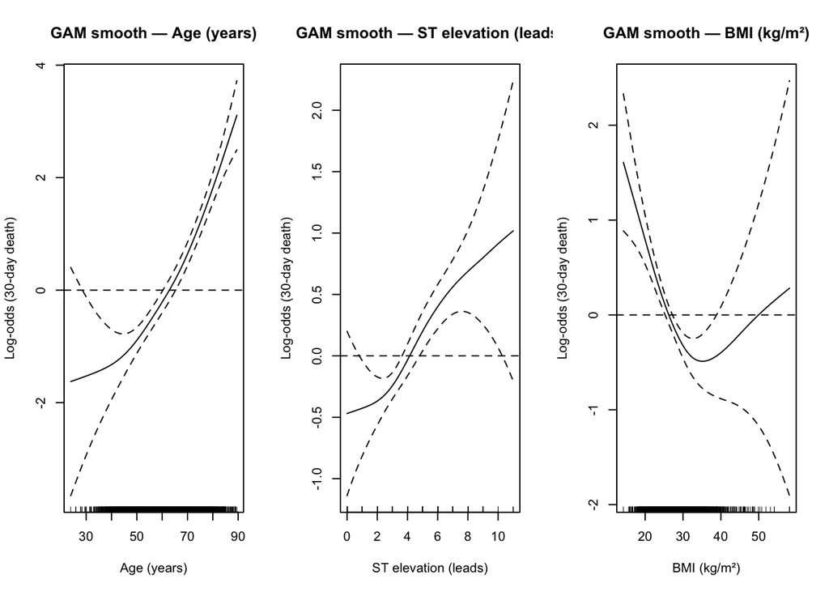

```r
plot_linearity <- function(var, xlab) {
  fit <- gam(as.numeric(day30) - 1 ~ s(get(var)), data = ami_data, family = binomial)
  plot(fit, se = TRUE, rug = TRUE,
       xlab = xlab, ylab = "Log-odds (30-day death)",
       main = paste("GAM smooth —", xlab))
  abline(h = 0, lty = 2)
}

par(mfrow = c(1, 3))
plot_linearity("age", "Age (years)")
plot_linearity("ste", "ST elevation (leads)")
plot_linearity("bmi", "BMI (kg/m²)")
```

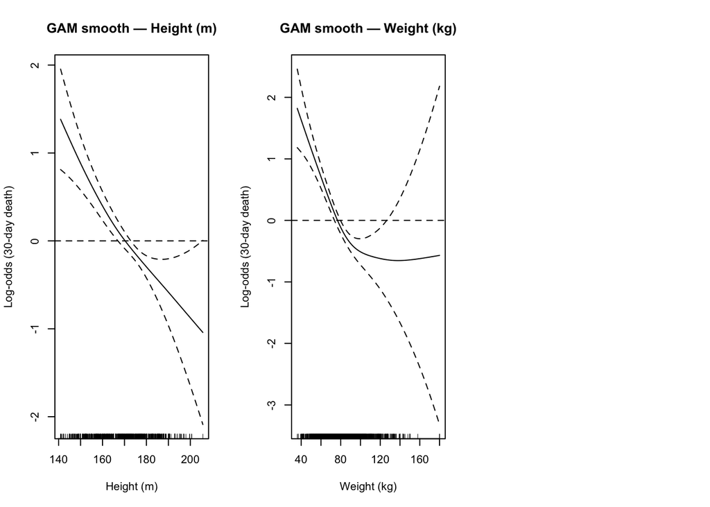

```r
plot_linearity("hei", "Height (m)")
plot_linearity("wei", "Weight (kg)")
par(mfrow = c(1, 1))
```